# Classification with Logistic Regression

Wybe Harms

# 1 Introduction

## 1.1 Load the data

First we need to start by loading the data.

```r
lc_raw <- read_csv(here::here("Data", "LendingClub Data.csv"), skip=1) %>%  #since the first row is a title we want to skip it.
  clean_names() # use janitor::clean_names()
```

# 2 ICE the data: Inspect, Clean, Explore

Any data science engagement starts with ICE. Inspecting, Clean and Explore the data.

## 2.1 Inspect the data

Inspect the data to understand what different variables mean. Variable definitions can be found in the excel version of the data.

```r
glimpse(lc_raw[, 1:10])
```

```
## Rows: 42,538
## Columns: 10
## $ int_rate    <dbl> 0.05, 0.05, 0.05, 0.05, 0.05, 0.05, 0.05, 0.05, 0.05, 0.05…
## $ loan_amnt   <dbl> 8000, 6000, 6500, 8000, 5500, 6000, 10200, 15000, 14750, 1…
## $ term_months <dbl> 36, 36, 36, 36, 36, 36, 36, 36, 36, 36, 36, 36, 36, 36, 36…
## $ installment <dbl> 241.28, 180.96, 196.04, 241.28, 165.88, 180.96, 307.63, 45…
## $ dti         <dbl> 2.11, 5.73, 17.68, 22.71, 5.75, 21.92, 18.62, 9.72, 18.32,…
## $ delinq_2yrs <dbl> 0, 0, 0, 0, 0, 0, 0, 0, 0, 0, 0, 0, 0, 0, 0, 0, 0, 0, 0, 0…
## $ annual_inc  <dbl> 50000, 52800, 35352, 79200, 240000, 89000, 110000, 135000,…
## $ grade       <chr> "A", "A", "A", "A", "A", "A", "A", "A", "A", "A", "A", "A"…
## $ emp_title   <chr> NA, "coral graphics", NA, "Honeywell", "O T Plus, Inc", "F…
## $ emp_length  <chr> "5 years", "< 1 year", "n/a", "n/a", "10+ years", "2 years…
```

## 2.2 Clean the data

Are there any redundant columns and rows? Are all the variables in the correct format (e.g., numeric, factor, date)? Lets fix it.

The variable `loan_status` contains information as to whether the loan has been repaid or charged off (i.e., defaulted). Let’s create a binary factor variable for this. This variable will be the focus of this workshop.

```r
lc_clean<- lc_raw %>%
  dplyr::select(-x20:-x80) %>% #delete empty columns
  filter(!is.na(int_rate)) %>%   #delete empty rows
  mutate(
    issue_d = mdy(issue_d),  # lubridate::mdy() to fix date format
    term = factor(term_months),     # turn 'term' into a categorical variable
    delinq_2yrs = factor(delinq_2yrs) # turn 'delinq_2yrs' into a categorical variable
  ) %>%
  mutate(default = dplyr::recode(loan_status,
                      "Charged Off" = "1",
                      "Fully Paid" = "0"))%>%
    mutate(default = as.factor(default),
           home_ownership = as.factor(home_ownership),
           verification_status = as.factor(verification_status),
           addr_state = as.factor(addr_state),
           issue_d = as.Date(issue_d)) %>%
  dplyr::select(-emp_title,-installment, -term_months, everything()) #move some not-so-important variables to the end.
```

## 2.3 Explore the data

Let’s explore loan defaults by creating different visualizations. We start with examining how prevalent defaults are, whether the default rate changes by loan grade or number of delinquencies, and a couple of scatter plots of defaults against loan amount and income.

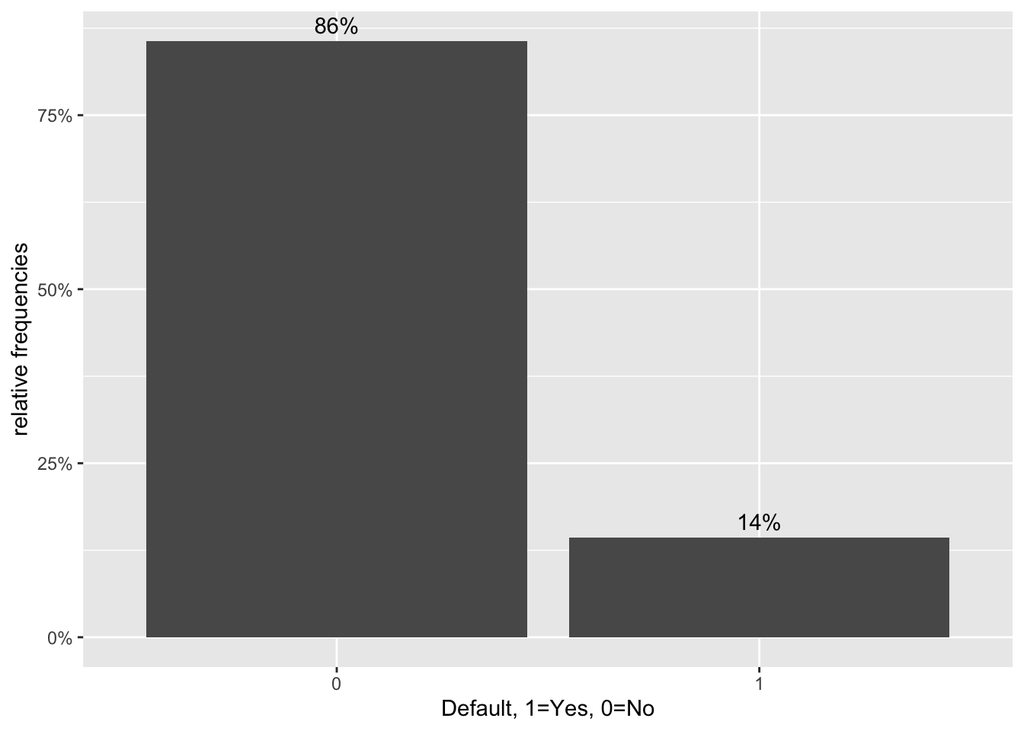

```r
# Bar chart of defaults
def_vis1<-ggplot(data=lc_clean, aes(x=default)) +geom_bar(aes(y = (..count..)/sum(..count..))) + labs(x="Default, 1=Yes, 0=No", y="relative frequencies") +scale_y_continuous(labels=scales::percent) +geom_text(aes( label = scales::percent((..count..)/sum(..count..) ),y=(..count..)/sum(..count..) ), stat= "count",vjust=-0.5)
def_vis1
```

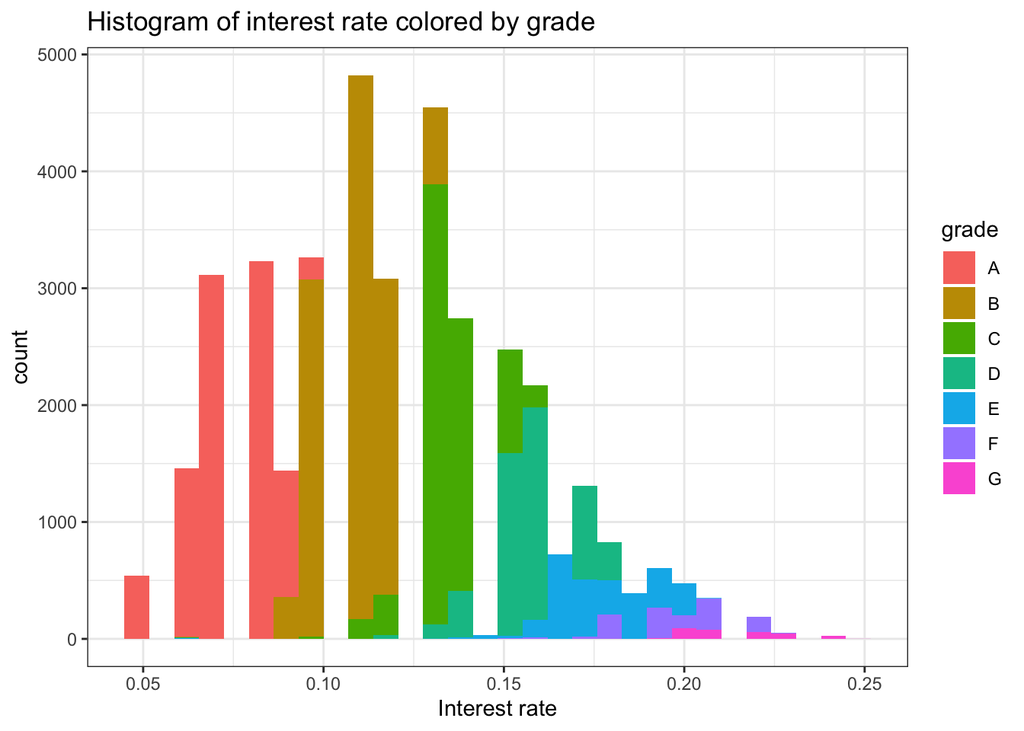

```r
# Build a histogram of interest rates but use different color for loans of different grades

def_vis6 <- ggplot(lc_clean,aes(int_rate)) +
  geom_histogram(aes(fill = grade)) +
  labs(title = "Histogram of interest rate colored by grade",
       x = "Interest rate") +
     theme_bw()
def_vis6
```

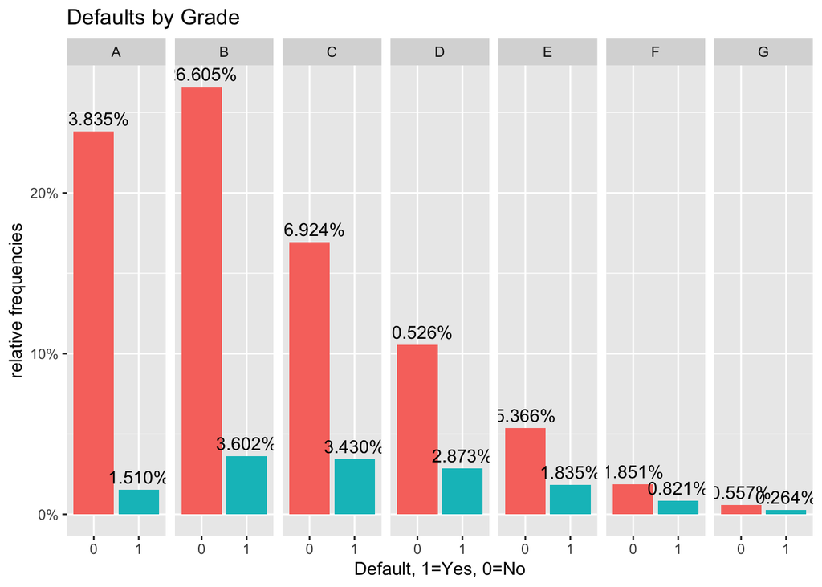

```r
# Bar chart of defaults per loan grade

def_vis2<-ggplot(data=lc_clean, aes(x=default), group=grade) +geom_bar(aes(y = (..count..)/sum(..count..), fill = factor(..x..)), stat="count")  + labs(title="Defaults by Grade", x="Default, 1=Yes, 0=No", y="relative frequencies") +scale_y_continuous(labels=scales::percent) +facet_grid(~grade) + theme(legend.position = "none") +geom_text(aes( label = scales::percent((..count..)/sum(..count..) ),y=(..count..)/sum(..count..) ), stat= "count",vjust=-0.5)
def_vis2
```

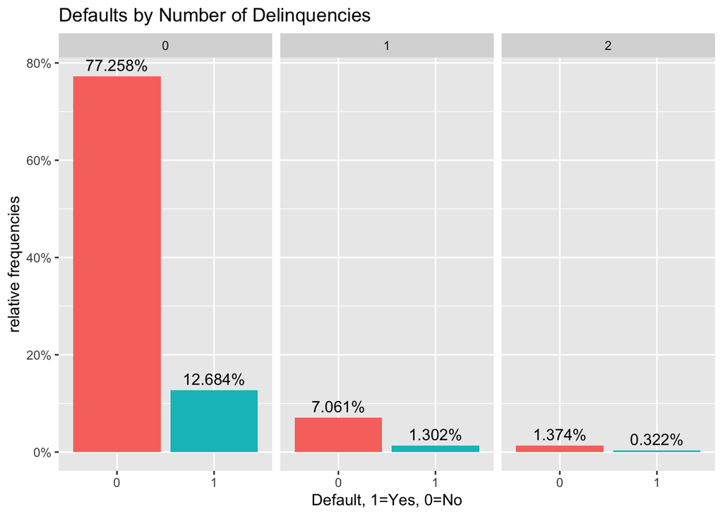

```r
# Bar chart of defaults per number of Delinquencies
def_vis3<-lc_clean %>%
  filter(as.numeric(delinq_2yrs)<4) %>%
  ggplot(aes(x=default), group=delinq_2yrs) +geom_bar(aes(y = (..count..)/sum(..count..), fill = factor(..x..)), stat="count")  + labs(title="Defaults by Number of Delinquencies", x="Default, 1=Yes, 0=No", y="relative frequencies")  +scale_y_continuous(labels=scales::percent) +facet_grid(~delinq_2yrs) + theme(legend.position = "none") +geom_text(aes( label = scales::percent((..count..)/sum(..count..) ),y=(..count..)/sum(..count..) ), stat= "count",vjust=-0.5)

def_vis3
```

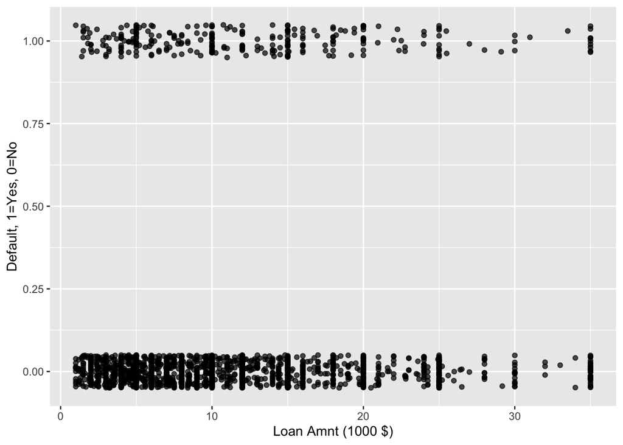

```r
#Scatter plots

# We select 2000 random loans to display only to make the display less busy.
set.seed(1234)
reduced<-lc_clean[sample(0:nrow(lc_clean), 2000, replace = FALSE),]%>%
  mutate(default=as.numeric(default)-1) # also convert default to a numeric {0,1} to make it easier to plot.


# Scatter plot of defaults against loan amount
def_vis4<-ggplot(data=reduced, aes(y=default,x=I(loan_amnt/1000)))  + labs(y="Default, 1=Yes, 0=No", x="Loan Amnt (1000 $)") +geom_jitter(width=0, height=0.05, alpha=0.7) #We use jitter to offset the display of defaults/non-defaults to make the data easier to interpert. We have also changed the amount to 1000$ to reduce the number of zeros on the horizontal axis.

def_vis4
```

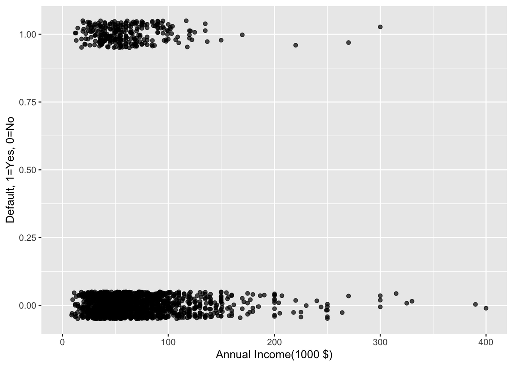

```r
# Scatter plot of defaults against loan amount.
def_vis5<-ggplot(data=reduced, aes(y=default,x=I(annual_inc/1000)))   + labs(y="Default, 1=Yes, 0=No", x="Annual Income(1000 $)") +geom_jitter(width=0, height=0.05, alpha=0.7) +  xlim(0,400)

def_vis5
```

We can also estimate a correlation table between defaults and other continuous variables.

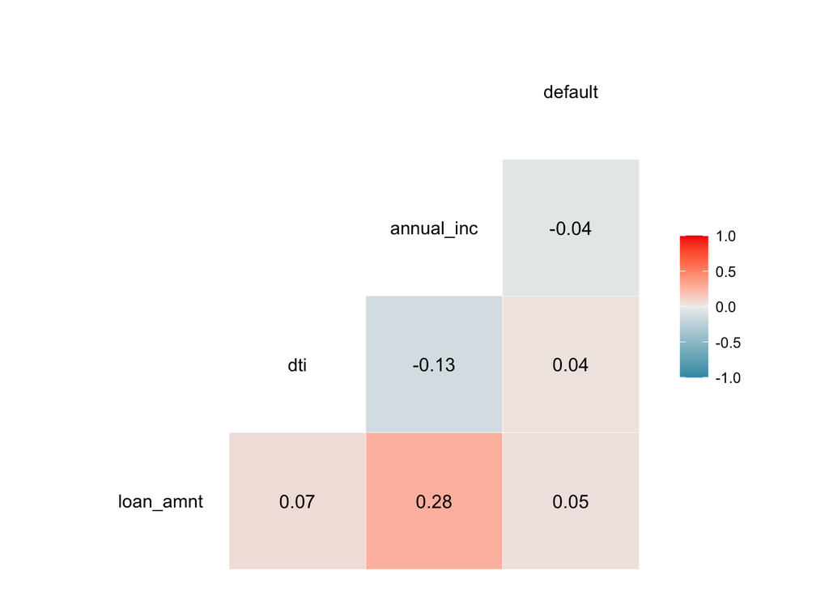

```r
# Correlation table using GGally::ggcor()

lc_clean %>%
    mutate(default=as.numeric(default)-1)%>%
  select(loan_amnt, dti, annual_inc, default) %>% #keep Y variable last
 ggcorr(method = c("pairwise", "pearson"), label_round=2, label = TRUE)
```

```r
def_vis8<-lc_clean%>%
  filter(emp_length %in% c("< 1 year","1 year","2 years", "3 years","4 years","5 years")) %>%
  ggplot(aes(x = annual_inc, y = int_rate, color= home_ownership))+
    geom_point()+
  geom_smooth(method = lm, se = FALSE)+
  scale_x_log10(labels = function(l) {
    trans = l / 1000})+
  labs(title = "Relationship bewteen income and interest rate by home ownership",
       y = "Interest Rate",
       x = "Annual income (1000 $)",
       color = "Home Ownership")+
       theme_bw()
def_vis8

# Bar chart of defaults per term
def_vis7<-lc_clean %>%
  ggplot(aes(x=default), group=term) +geom_bar(aes(y = (..count..)/sum(..count..), fill = factor(..x..)), stat="count")  + labs(title="Defaults by Term", x="Default, 1=Yes, 0=No", y="Relative Frequencies")  +scale_y_continuous(labels=scales::percent) +facet_grid(~term) + theme(legend.position = "none") +geom_text(aes( label = scales::percent((..count..)/sum(..count..) ),y=(..count..)/sum(..count..) ), stat= "count",vjust=-0.5)

def_vis7
```

[output not shown]

# 3 Linear vs. logistic regression for binary response variables

It is certainly possible to use the OLS approach to find the line that minimizes the sum of squared errors when the dependent variable is binary (i.e., default / no default). In this case, the predicted values take the interpretation of a probability. We can also estimate a logistic regression instead. We do both below.

```r
model_lm<-lm(as.numeric(default)~I(annual_inc/1000), lc_clean)
summary(model_lm)
```

```
##
## Call:
## lm(formula = as.numeric(default) ~ I(annual_inc/1000), data = lc_clean)
##
## Residuals:
##     Min      1Q  Median      3Q     Max
## -0.1595 -0.1494 -0.1444 -0.1332  1.3268
##
## Coefficients:
##                      Estimate Std. Error t value Pr(>|t|)
## (Intercept)         1.161e+00  2.703e-03 429.312   <2e-16 ***
## I(annual_inc/1000) -2.479e-04  2.918e-05  -8.496   <2e-16 ***
## ---
## Signif. codes:  0 '***' 0.001 '**' 0.01 '*' 0.05 '.' 0.1 ' ' 1
##
## Residual standard error: 0.3501 on 37867 degrees of freedom
## Multiple R-squared:  0.001903,   Adjusted R-squared:  0.001876
## F-statistic: 72.19 on 1 and 37867 DF,  p-value: < 2.2e-16
```

```r
logistic1<-glm(default~I(annual_inc/1000), family="binomial", lc_clean)
summary(logistic1)
```

```
##
## Call:
## glm(formula = default ~ I(annual_inc/1000), family = "binomial",
##     data = lc_clean)
##
## Deviance Residuals:
##     Min       1Q   Median       3Q      Max
## -0.6246  -0.5786  -0.5572  -0.5115   3.6388
##
## Coefficients:
##                      Estimate Std. Error z value Pr(>|z|)
## (Intercept)        -1.5191545  0.0292430  -51.95   <2e-16 ***
## I(annual_inc/1000) -0.0040801  0.0003998  -10.21   <2e-16 ***
## ---
## Signif. codes:  0 '***' 0.001 '**' 0.01 '*' 0.05 '.' 0.1 ' ' 1
##
## (Dispersion parameter for binomial family taken to be 1)
##
##     Null deviance: 31130  on 37868  degrees of freedom
## Residual deviance: 31005  on 37867  degrees of freedom
## AIC: 31009
##
## Number of Fisher Scoring iterations: 5
```

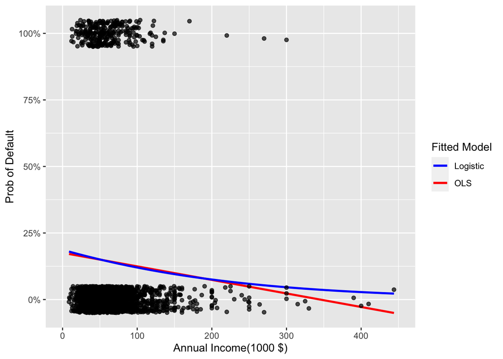

```r
ggplot(data=reduced, aes(x=I(annual_inc/1000), y=default)) + geom_smooth(method="lm", se=0, aes(color="OLS"))+ geom_smooth(method = "glm", method.args = list(family = "binomial"),  se=0, aes(color="Logistic"))+ labs(y="Prob of Default", x="Annual Income(1000 $)")+  xlim(0,450)+scale_y_continuous(labels=scales::percent)+geom_jitter(width=0, height=0.05, alpha=0.7) + scale_colour_manual(name="Fitted Model", values=c("blue", "red"))
```

> Discuss which model is more suitable for predicting probability of default

The logistic model is clearly the better model to use because it returns a probability value that is between 0-1. Since the linear regression is linear, a very large or small value of X could lead to a probability the is less than 0 (ex. income is greater than 350,000 then estimated probability is negative) or more than 1. This is obviously not possible. This can be seen by the blue curve (logistic) curving more horizontally to stay above 0 probability as income increases.

# 4 Multivariate logistic regression

We can estimate logistic regression with multiple explanatory variables as well. Let’s use annual_inc, term, grade, and loan amount as features. Let’s call this model logistic 2.

```r
logistic2<-glm(default~I(annual_inc/1000) + term + grade +loan_amnt, family="binomial", lc_clean)
summary(logistic2)
```

```
##
## Call:
## glm(formula = default ~ I(annual_inc/1000) + term + grade + loan_amnt,
##     family = "binomial", data = lc_clean)
##
## Deviance Residuals:
##     Min       1Q   Median       3Q      Max
## -1.0635  -0.6079  -0.4815  -0.3455   4.0988
##
## Coefficients:
##                      Estimate Std. Error z value Pr(>|z|)
## (Intercept)        -2.432e+00  5.056e-02 -48.093   <2e-16 ***
## I(annual_inc/1000) -6.019e-03  4.727e-04 -12.733   <2e-16 ***
## term60              4.790e-01  3.561e-02  13.451   <2e-16 ***
## gradeB              6.599e-01  5.270e-02  12.521   <2e-16 ***
## gradeC              1.031e+00  5.392e-02  19.128   <2e-16 ***
## gradeD              1.288e+00  5.703e-02  22.578   <2e-16 ***
## gradeE              1.415e+00  6.662e-02  21.241   <2e-16 ***
## gradeF              1.666e+00  8.630e-02  19.302   <2e-16 ***
## gradeG              1.769e+00  1.340e-01  13.198   <2e-16 ***
## loan_amnt           2.841e-06  2.347e-06   1.211    0.226
## ---
## Signif. codes:  0 '***' 0.001 '**' 0.01 '*' 0.05 '.' 0.1 ' ' 1
##
## (Dispersion parameter for binomial family taken to be 1)
##
##     Null deviance: 31130  on 37868  degrees of freedom
## Residual deviance: 29286  on 37859  degrees of freedom
## AIC: 29306
##
## Number of Fisher Scoring iterations: 5
```

```r
#compare the fit of logistic 1 and logistic 2
anova(logistic1,logistic2)
```

| Resid. Df | Resid. Dev | Df | Deviance |
| --- | --- | --- | --- |
| 3.79e+04 | 3.1e+04 |  |  |
| 3.79e+04 | 2.93e+04 | 8 | 1.72e+03 |

The logistic curve is created by plugging a linear function of coefficients (B) and variables (X) called the expected risk (or log odds), into a logistic response function. This logistic function squashes the linear function to return a probability of Y happening between 0 and 1. However, how do we estimate the values of the coefficients?

The relationship between Y and the coefficients (B) is non-linear, meaning we cannot use the method of least squares to optimize the coefficients as this would return a straight line. Instead, we use the maximum likelihood method. This multiplies the independent probabilities of Y happening given each value of X, times its coefficient B. The computer chooses certain combination of coefficient and multiplies it by all the X values, and then calculates the probability. When summing all those probabilities, we will eventually get the likelihood of Y happening for that particular combination of coefficients. This process is repeated (using computational power) until it returns the combination of coefficients that have the highest likelihood, in other words, the maximum likelihood. It must be mentioned that we actually use log likelihood to calculate the optimal coefficient values, because it sums the probabilities instead of multiplying them (by multiplying each probability, you will run out of floating point precision very quickly).

We can assess the uncertainty of each explanatory variable by looking at the standard error. This tells us how much “noise” there is, while the coefficient of the explanatory variable tells us how much “signal” there is. We know that the log odds for one beta is log(p/1-p), which means that when you insert a probability into log odds, you will get the value of the beta. To calculate the standard error for beta, we use the delta method which leads to dividing the SE(p) by p(1-p).

The downside of model 2 is that it includes a non-significant variable. Loan amount does not add relevant explanatory power to the model since it has a z-score of less than 2 and therefore a p-value that is greater than 5% (meaning we accept the hypothesis that a change in loan amount will not change the likelihood of getting Y). The z-value is derived from dividing the coefficient by the standard error. In the case of loan amount, the coefficient, which is its explanatory value (signal), and the standard error, which tells us how much variability there is (noise), are almost the same value which generates z-value of less than 2.

> Calculate the predicted probabilities associated with logistic 2 and plot as a density chart.

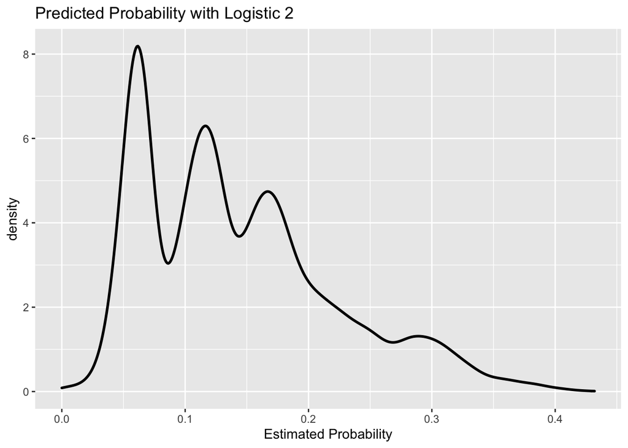

```r
#Predict the probability of default
prob_default2<-predict(logistic2,lc_clean,type="response")

#plot 1: Density of predictions
g0<-ggplot( lc_clean, aes( prob_default2 ) )+
  geom_density( size=1)+
  ggtitle( "Predicted Probability with Logistic 2" )+  xlab("Estimated Probability")
g0
```

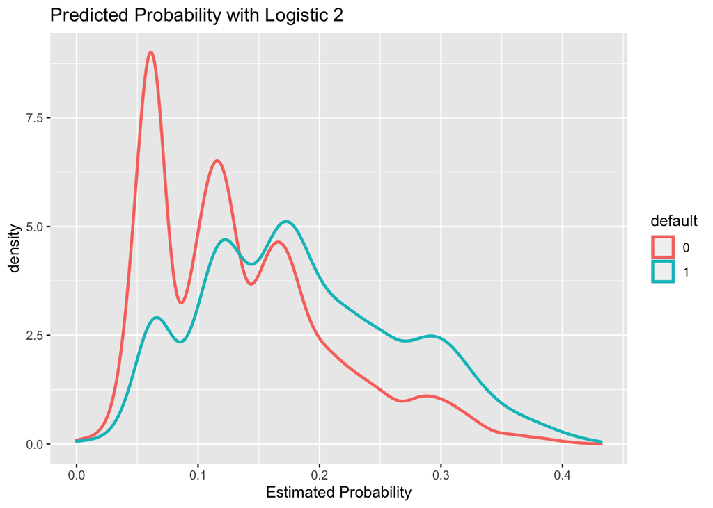

```r
#plot 2: Density of predictions by default
g1<-ggplot( lc_clean, aes( prob_default2, color=default) ) +
  geom_density(size=1)+
  ggtitle( "Predicted Probability with Logistic 2" )+  xlab("Estimated Probability")
g1
```

The first chart (g0) shows us the density of estimations for a given probability, regardless of it being default or not. This second chart (g1) is more interesting because it reveals how the model gives different probabilities for both loans. The red line being very dense at low estimated prob means that the model is quite good at predicting a loan not defaulting, to actually not default. The green line on the other hand is a bit worse. The model is not great at predicting defaulted loans as the density is spread out.

A perfect model would have complete density of the red curve on the left (non defaulting loans always receive an estimated probability of 0) and complete density of the green curve on the right (all the defaulting loans receive an estimated probability of 1 of defaulting). In this case, only the red line is rather skewed, meaning that our model is ok, but not great.

Interestingly we observe bumps on both curves occurring at the same level on the x-axis. This could be explained by the different types of grades. For example, the first bump is probably caused by Grade A loans as these tend to receive the lowest chance of defaulting. The Grade A loans are concentrated around a probability of around 7.5%. We know from the z-values in the regression model that the grade level is a significant explanatory variable. In model 2, grade level is included as a parameter which means that the “expected risk”, or log odds, will vary significant for each category of grade (assuming the other parameters remain constant). Thus, if we use the expected risk to calculate the probability, we will get a concentration of probabilities at each grade level.

## 4.1 From probability to classification

The logistic regression model gives us a sense of how likely defaults are; it gives us a probability estimate. To convert this into a prediction, we need to choose a cutoff probability and classify every loan with a predicted probability of default above the cutoff as a prediction of default (and as a prediction of non-default for loans with a predicted probability below this cutoff).

Let’s choose a threshold of 19.5%. Of course some of our predictions will turn out to be right but some will turn out to be wrong – you can see this in the density figures of the previous section. Let’s call “default” the “positive” class since this is the class we are trying to predict. We could be making two types of mistakes. False positives (i.e., predict that a loan will default when it will not) and false negatives (I.e., predict that a loan will not default when it will). These errors are summarized in the confusion matrix.

> Produce a confusion matrix for the model logistic 2 for a cutoff of 19.5%

```r
#using the logistic 2 model predict default probabilities
prob_default2<- predict(logistic2,lc_clean,type="response")

#Call any loan with probability more than 19.5% as default and any loan with lower probability as non-default.
one_or_zero<-ifelse(prob_default2>0.195,"1","0")

#Make sure your prediction is a factor with the same levels as the default variable in the lc_clean data frame
p_class<-factor(one_or_zero,levels=levels(lc_clean$default))

#produce the confusion matrix and set default as the positive outcome
con2<- confusionMatrix(p_class, lc_clean$default,positive="1")
#p_class is the prediction of default (according to cut_off of 19.5%)
#lc_clean$default is the actual value of default
con2
```

```
## Confusion Matrix and Statistics
##
##           Reference
## Prediction     0     1
##          0 26184  3206
##          1  6256  2223
##
##                Accuracy : 0.7501
##                  95% CI : (0.7457, 0.7545)
##     No Information Rate : 0.8566
##     P-Value [Acc > NIR] : 1
##
##                   Kappa : 0.1756
##
##  Mcnemar's Test P-Value : <2e-16
##
##             Sensitivity : 0.4095
##             Specificity : 0.8072
##          Pos Pred Value : 0.2622
##          Neg Pred Value : 0.8909
##              Prevalence : 0.1434
##          Detection Rate : 0.0587
##    Detection Prevalence : 0.2239
##       Balanced Accuracy : 0.6083
##
##        'Positive' Class : 1
##
```

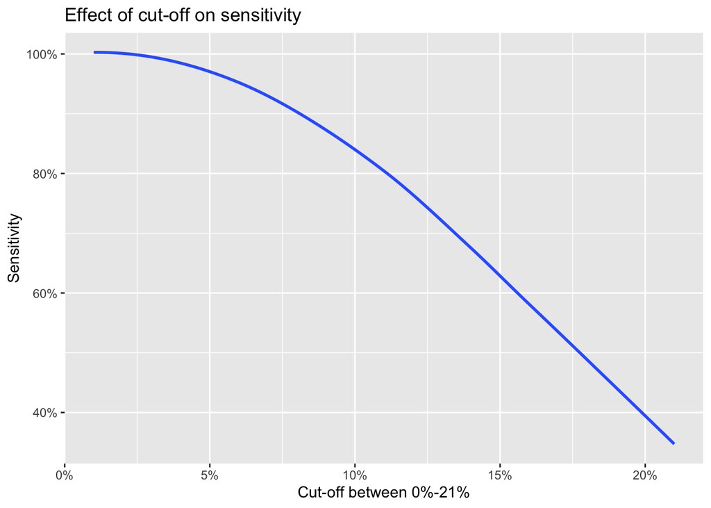

```r
sensitivity=0
specificity=0
threshold=0.125
for(i in 1:21) {
  threshold[i]=i/100
  one_or_zero_search<-ifelse(prob_default2>threshold[i],"1","0")
  p_class_search<-factor(one_or_zero_search,levels=levels(lc_clean$default))
  con_search<-confusionMatrix(p_class_search,lc_clean$default,positive="1")
  sensitivity[i]=con_search$byClass[1]
  specificity[i]=con_search$byClass[2]
}

ggplot(as.data.frame(threshold), aes(x=threshold,y=sensitivity)) + geom_smooth(method = 'loess', se=0)+
  labs(title = "Effect of cut-off on sensitivity", y = "Sensitivity", x = "Cut-off between 0%-21%")+
  scale_x_continuous(labels = scales::percent)+
  scale_y_continuous(labels = scales::percent)
```

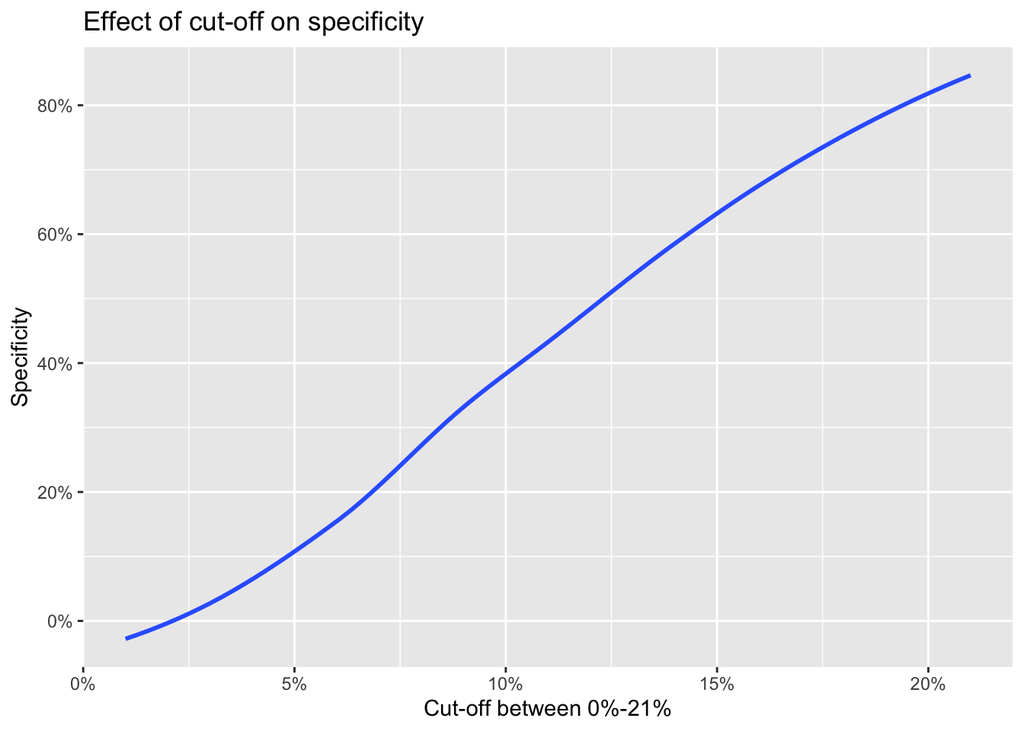

```r
ggplot(as.data.frame(threshold), aes(x=threshold,y=specificity)) + geom_smooth(method = 'loess', se=0)+
  labs(title = "Effect of cut-off on specificity", y = "Specificity", x = "Cut-off between 0%-21%")+
  scale_x_continuous(labels = scales::percent)+
  scale_y_continuous(labels = scales::percent)
```

> Explain how accuracy, Sensitivity and Specificity are calculated

If we were to set a cut off of 100%, every instance being no default, the accuracy will be 85.66% as this is the same amount of loans that actually did not default. In turn, the sensitivity (true 1’s) will be 0% correct as none of loans are predicted as defaulted, while specificity (true 0’s) will be 100% correct, as all the loans are predicted to not default.

If we switch it around and set the cut-off at 0%, every instance being a default, we will get an accuracy of 14.34% which is the same amount of loans that actually did default. Now the sensitivity will be 100% correct, as all loans were predicted to default, and specificity will be 0% correct as none of loans were predicted to not default.

Deciding which cut off to use will depend on the cost associated to predicting it wrong. In the case of the lending club, we can assume that predicting a loan to not default, but it actually defaulting, will be quite costly. For this reason, we will want to set a cut off that returns a high sensitivity (predict most of the defaulted loans correctly). If we had a situation where predicting a false positive is much more costly, for example convicting an innocent person of committing a crime, then we will want to set a cut off that maximizes specificity as to reduce the number of false positives.

Kappa compares the performance of any classifier to the “random classifier” by dividing accuracy - random accuracy by 1 - random accuracy. This means that if your accuracy is 1, then kappa will also be 1 (as random accuracy will be 0). A kappa of 0 would indicate your model is random (as this is the random baseline). In this case we have a kappa of 0.1756 which means our model is 17.56% on the way to a perfect model.

> Produce ab ROC curve and calculate the AUC measure.

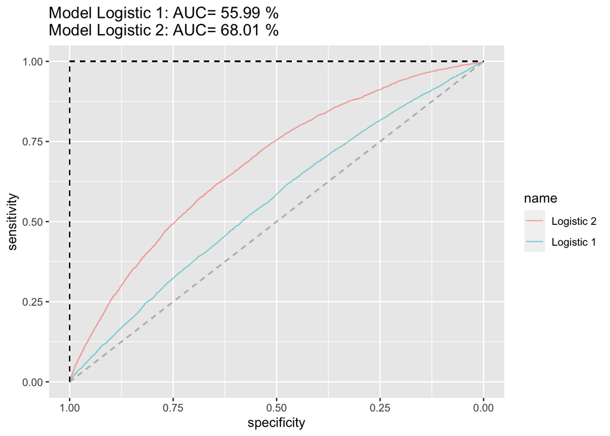

```r
#estimate the ROC curve for Logistic 2
ROC_logistic2 <-roc(lc_clean$default,prob_default2) # the first argument is a vector of outcomes and the second is a vector of probabilities associated with each outcome
#estimate the AUC for Logistic 2 and round it to two decimal places
AUC2<-round(auc(lc_clean$default, prob_default2)*100, digits = 2)
p1<-predict(logistic1, lc_clean, type = "response")
ROC_logistic1 <- roc(lc_clean$default,p1)
#Plot the ROC curve and display the AUC in the title
ROC2<-ggroc(list("Logistic 2"=ROC_logistic2, "Logistic 1"=ROC_logistic1),  alpha = 0.5)+
  ggtitle(paste("Model Logistic 1: AUC=",round(auc(lc_clean$default,p1)*100, digits=2),"%\nModel Logistic 2: AUC=",round(auc(lc_clean$default,prob_default2)*100, digits=2),"%"))  +
geom_segment(aes(x = 1, xend = 0, y = 0, yend = 1), color="grey", linetype="dashed")+
  geom_segment(aes(x = 1, xend = 1, y = 0, yend = 1), color="black", linetype="dashed")+
  geom_segment(aes(x = 1, xend = 0, y = 1, yend = 1), color="black", linetype="dashed")
ROC2
```

The greater the area under the curve, the better because the model is more accurate at predicting (when AUC is high then specificity and sensitivity will also be higher). However, you cannot choose the cut-off based simply on the point where specificity and sensitivity are a combined highest. The cut-off is purely dependent on the cost associated to having a low specificity vs low sensitivity. In the case of loans, having a low sensitivity (many false positives is very bad because predicting a loan to not default while it actually does default is very expensive).

Here we can also see that for any given specificity or sensitivity, model 2 (red curve) performs better than model 1 (blue curve). In other words, model2 is simply better at predicting. Theoretically, the best ROC curve will have 100% specificity and 100% sensitivity at any cut-off, and thus have an AUC of 100%. This means the model will always correctly predict the Y value.

> Split the data into training and testing and estimate the models ROC curve and AUC measure out of sample. Discuss evidence of overfitting?

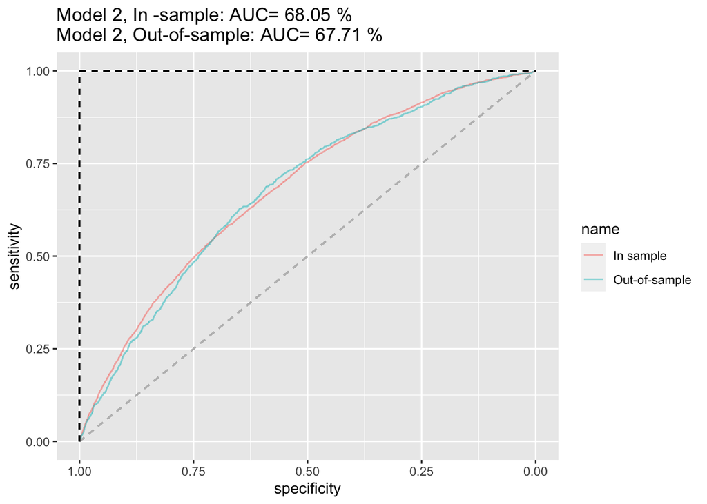

```r
# splitting the data into training and testing
set.seed(1234)
train_test_split <- initial_split(lc_clean, prop = 0.8)
testing <- testing(train_test_split) #20% of the data is set aside for testing
training <- training(train_test_split) #80% of the data is set aside for training

# run logistic 2 on the training set
logistic2<-glm(default~annual_inc + term + grade + loan_amnt, family="binomial", training)

#calculate probability of default in the training sample
p_in<-predict(logistic2, training, type = "response")

#ROC curve using in-sample predictions
ROC_logistic2_in <-roc(training$default,p_in)
#AUC using in-sample predictions
AUC_logistic2_in<-round(auc(training$default, p_in)*100, digits = 2)
#calculate probability of default out of sample
p_out<- predict(logistic2, testing, type = "response")

#ROC curve using out-of-sample predictions
ROC_logistic2_out <- roc(testing$default,p_out)
#AUC using out-of-sample predictions
AUC_logistic2_out <- round(auc(testing$default, p_out)*100, digits = 2)
#plot in the same figure both ROC curves and print the AUC of both curves in the title

ROC3<-ggroc(list("In sample"=ROC_logistic2_in, "Out-of-sample"=ROC_logistic2_out),  alpha = 0.5)+
  ggtitle(paste("Model 2, In -sample: AUC=",round(auc(training$default, p_in)*100, digits = 2),"%\nModel 2, Out-of-sample: AUC=",round(auc(testing$default, p_out)*100, digits = 2),"%"))  +
geom_segment(aes(x = 1, xend = 0, y = 0, yend = 1), color="grey", linetype="dashed")+
  geom_segment(aes(x = 1, xend = 1, y = 0, yend = 1), color="black", linetype="dashed")+
  geom_segment(aes(x = 1, xend = 0, y = 1, yend = 1), color="black", linetype="dashed")
ROC3
```

The total area under the curve is slightly larger when we run the model on the training set versus running it on the testing set. Interestingly though, the ROC curve of the in-sample doesn’t always return a higher sensitivity for a given specificity. For example, at a specificity of 55%, the out-of-sample test returns a higher sensitivity. This can be explained by the fact that the data in the testing set is slightly different and that model 2 happens to predict those data points better.

Nevertheless, the out-of-sample model performs slightly worse than the in-sample, although this is very minimal. This indicates that the model over-fits a tiny bit when it is trained using the training data. This causes the model to perform a bit worse when it needs to predict new data points.

## 4.2 Selecting loans to invest in using the model Logistic 2.

Before we look for a better model than logistic 2 let’s see how we can use this model to select loans to invest in. Let’s make the simplistic assumption that every loan generates $18 profit if it is paid off and $85 loss if it is charged off for an investor. Let’s use a cut-off value to determine which loans to invest in, that is, if the predicted probability of default for a loan is below this value then we invest in that loan and not if it is above.

To do this we split the data in three parts: training, validation, and testing. Feel free to experiment with different seeds but please use the seeds provided below for your submission.

```r
# splitting the data into training and testing
set.seed(1234)
train_test_split <- initial_split(lc_clean, prop = 0.6)
training <- training(train_test_split) #60% of the data is set aside for training
remaining <- testing(train_test_split) #40% of the data is set aside for validation & testing
set.seed(4321)
train_test_split <- initial_split(remaining, prop = 0.5)
validation<-training(train_test_split) #50% of the remaining data (20% of total data) will be used for validation
testing<-testing(train_test_split) #50% of the remaining data (20% of total data) will be used for testing
```

Re-run this to shuffle the data between validation and test data.

> Train logistic 2 on the training set above. Using the trained model to determine the optimal cut-off threshold based on the validation test

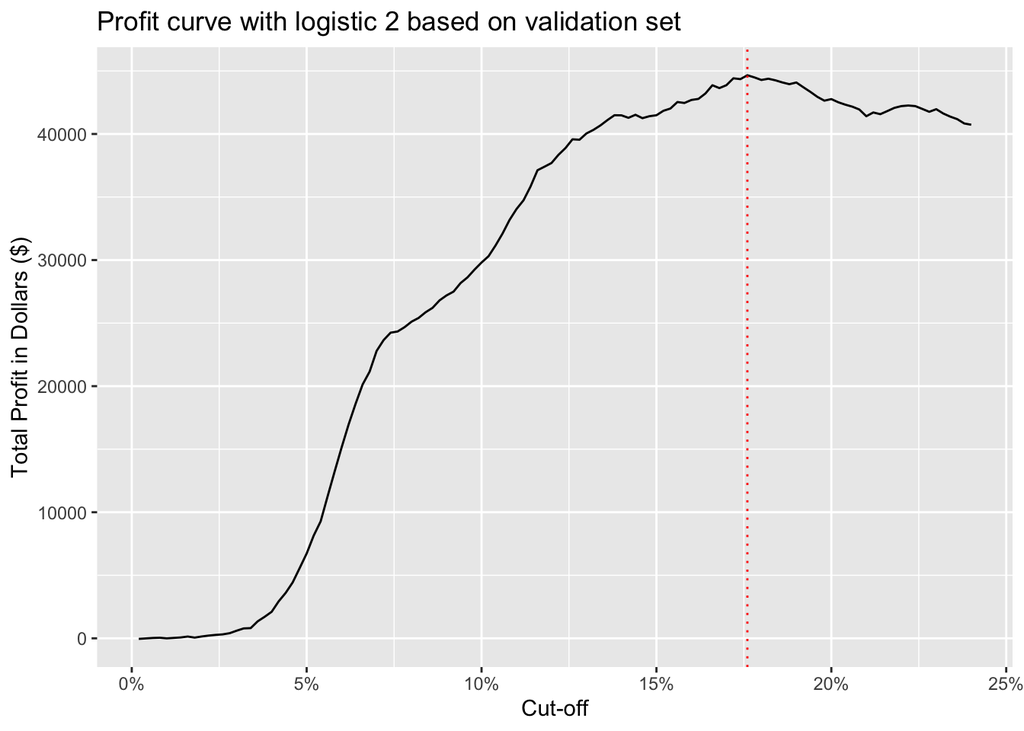

```r
#we calculate the optimal cut-off using the out-of-sample regression (validation set)

#Run model 2 on the new training set
logistic2<-glm(default~annual_inc + term + grade + loan_amnt, family="binomial", training)

#Use the model made using the training set to predict the validation set
p_val<-predict(logistic2, validation, type = "response")

profit=0
threshold=0
for(i in 1:120) {
  threshold[i]=i/500
  one_or_zero_search<-ifelse(p_val>threshold[i],"1","0")
  p_class_search<-factor(one_or_zero_search,levels=levels(validation$default))
  con_search<-confusionMatrix(p_class_search,validation$default,positive="1")
  profit[i]=con_search$table[1,1]*18-con_search$table[1,2]*85
}

ggplot(as.data.frame(threshold), aes(x=threshold,y=profit)) + geom_line(method = 'loess', se=0) +labs(title="Profit curve with logistic 2 based on validation set", y="Total Profit in Dollars ($)", x = "Cut-off")+
  geom_vline(xintercept=c(0.176), color = "red", linetype="dotted")+
  scale_x_continuous(labels = scales::percent)
```

```r
paste0("Based on the validation set: Maximum profit per loan is $", round(max(profit)/nrow(validation),2), " achieved at a threshold of ", threshold[which.is.max(profit)]*100,"%.")
```

```
## [1] "Based on the validation set: Maximum profit per loan is $5.9 achieved at a threshold of 17.6%."
```

The above profit curve shows us how much profit the firm would make for a given cut-off. To start we can look at the two extremes. With a 0% cut-off, each loan is predicted to default, meaning the firm will not lose any more by predicting the wrong loans, but in turn it would also not make any money by predicting the loans correctly. Hence, the profit would be zero. The moment that the cut-off increases to above zero, the profit can either be positive or negative. The other extreme, a 100% cut off, will actually generate a significant profit. In this case all the loans will be predicted to not default, meaning that the 14% of loans that did actually default will incur a loss of 85$ each. However, the other 86% of the loans that did not actually default will generate a profit of 18$ and eventually cancel out the losses and actually return a net profit.

It is possible to maximize profit by setting a specific threshold. This is at a cut-off of 17.6%, which leads to an average profit per loan of $5.9.

# 5 More realistic revenue model

Let’s build a more realistic profit and loss model. Each loan has different terms (e.g., different interest rate and different duration) and therefore a different return if fully paid. For example, a 36 month loan of $5000 with installment of $163 per month would generate a return of `163*36/5000-1` if there was no default. Let’s assume that it would generate a loss of -65% if there was a default (the loss is not 100% because the loan may not default immediately and/or the lending club may be able to recover part of the loan).

> Return per $1 invested

```r
# Add p_val to information to validation set. Then add profit for each loan and loss for each loan. Use this to calculate the expected profit and expected return for each loan.

validation_actual <- validation%>%
  mutate(percentage_default = p_val,
         actual_return = ifelse(default == 0,
                                installment*term_months/loan_amnt-1,
                                -0.65))

invest_1dollar <-validation_actual%>%
  summarize(net_profit = sum(actual_return),
            return = 100*(net_profit/nrow(validation_actual)))
invest_1dollar
```

| net_profit | return |
| --- | --- |
| 827 | 10.9 |

If we invested 1$ in each loan, we would invest a total of 7574$. The absolute profit that we would make from this is 827.05$, which when we convert to a % return would be a 10.92% return on our investment, not bad!.

> Assume that each time there is default we further incure a fixed cost of $ $C$ in addition to the 65% loss. What is the maximum amount of $C$ which would still give a positive mean return in the previous setting (*i.e.*, investing $ 1 in each loan).

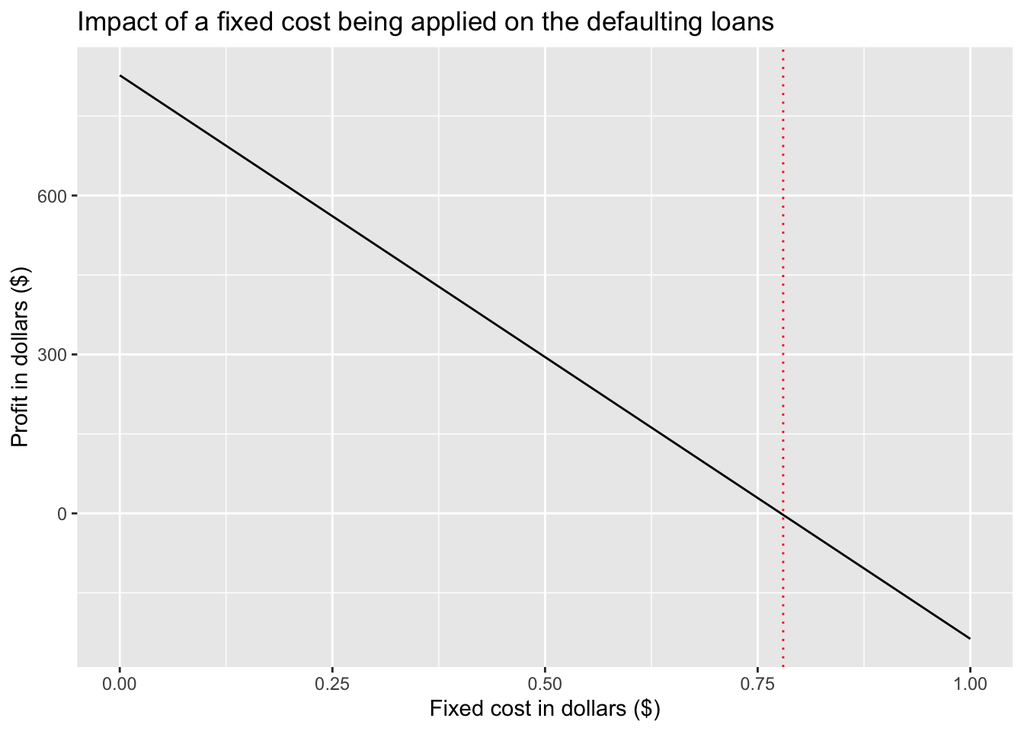

```r
#Give variables fixed numbers
total_profit = sum(validation_actual$actual_return)
amnt_invested = nrow(validation_actual)
n_default = sum(validation_actual$default == 1)

#Create two vectors
#fixed_cost_vector has 100 elements from 0 to 1
#profit_vector is empty and will fill up for each loop that you run

fixed_cost_vector <- c(seq(0, 1, by=0.01))
profit_vector <- c()
for (i in 1:length(fixed_cost_vector)){
  new_profit <- total_profit - fixed_cost_vector[i]*n_default
  profit_vector[i] <- new_profit
}

#Combine by creating df
df_fc <- data.frame(fixed_cost_vector, profit_vector)

ggplot(df_fc, aes(x = fixed_cost_vector, y = profit_vector)) +
  geom_line() +
  geom_vline(xintercept = fixed_cost_vector[which.min(abs(profit_vector))], color = "red", linetype="dotted") +
  labs(title = "Impact of a fixed cost being applied on the defaulting loans",
       x = "Fixed cost in dollars ($)",
       y = "Profit in dollars ($)")
```

```r
paste0("Based on the validation set: A fixed cost of $", fixed_cost_vector[which.min(abs(profit_vector))], " will cause profit to be equal to zero")
```

```
## [1] "Based on the validation set: A fixed cost of $0.78 will cause profit to be equal to zero"
```

The above visual reveals how an increase in an additional fixed cost for each defaulting loan leads to a lower profit. As we calculated before, our profit without a fixed cost would be 827.05$. When we apply a fixed cost of say 10 cents to each defaulting loan (there are 1064 of them), the profit will drop by 106.4 dollars (1064*0.10). Eventually, the profit will remain positive until we reach a fixed cost of $0.78.

From here onward, drop the assumption of an additional fixed cost as introduced in Q11 and take the revenue model introduced in Q10. Unfortunately, we cannot use the realized return to select loans to invest (as at the time we make the investment decision we do not know which loan will default). Instead, we can calculate an expected return using the estimated probabilities of default – expected return = return if not default * (1-prob(default)) + return if default * prob(default).

> Calculate the expected return of the loans in the validation set using the logistic 2 model trained in the training set

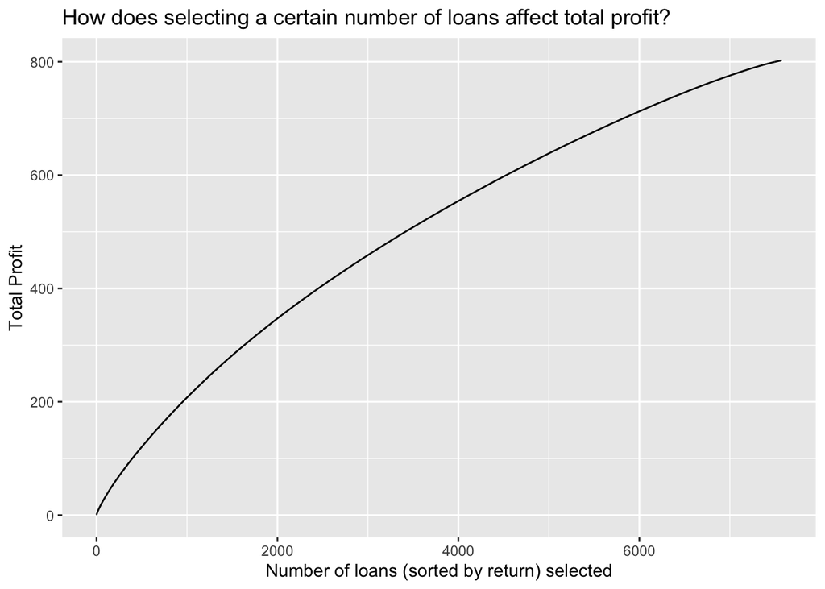

```r
validation_expected <- validation%>%
  mutate(percentage_default = p_val,
         profit = installment*term_months-loan_amnt-1,
         loss = loan_amnt*0.65,
         expected_profit = profit*(1-percentage_default) - loss*percentage_default,
         expected_return = expected_profit/loan_amnt)

n_loans_vector <- c(seq(0, 7574, by=1))
profit_vector <- c()
for (i in 1:length(n_loans_vector)){
  new_profit <- sum(as.vector(sort((validation_expected$expected_return), decreasing = TRUE))[1:n_loans_vector[i]])
  profit_vector[i] <- new_profit
}

df_n_loans <- data.frame(n_loans_vector, profit_vector)

ggplot(df_n_loans, aes(n_loans_vector, profit_vector)) +
  geom_line()+
  labs(title = "How does selecting a certain number of loans affect total profit?",
       x = "Number of loans (sorted by return) selected",
       y  = "Total Profit")
```

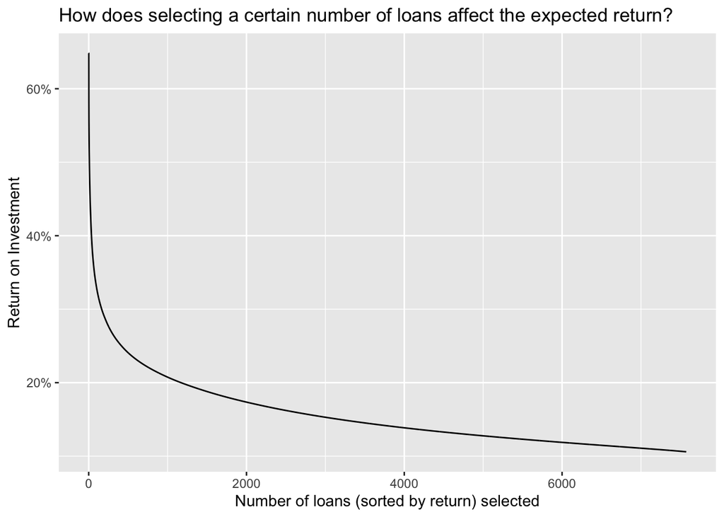

```r
n_loans_vector <- c(seq(0, 7574, by=1))
profit_return_vector <- c()
for (i in 1:length(n_loans_vector)){
  new_profit <- mean(as.vector(sort((validation_expected$expected_return), decreasing = TRUE))[1:n_loans_vector[i]])
  profit_return_vector[i] <- new_profit
}

df_n_loans_mean <- data.frame(n_loans_vector, profit_return_vector)

ggplot(df_n_loans_mean, aes(n_loans_vector, profit_return_vector)) +
  geom_line()+
  scale_y_continuous(labels=scales::percent)+
  labs(title = "How does selecting a certain number of loans affect the expected return?",
       x = "Number of loans (sorted by return) selected",
       y  = "Return on Investment")
```

```r
paste0("Based on the validation set: The average return  for the top 750 loans is ", round(mean(as.vector(sort(100*(validation_expected$expected_return), decreasing = TRUE))[1:750]), 2), "% with the total profit if you invested one dollar in each loan, so 750$ in total, being $", round(sum(as.vector(sort((validation_expected$expected_return), decreasing = TRUE))[1:750]),2))
```

```
## [1] "Based on the validation set: The average return  for the top 750 loans is 22.12% with the total profit if you invested one dollar in each loan, so 750$ in total, being $165.87"
```

Here we have first visualized how selecting a certain number of loans will increase total profit. Since almost all the loans are “expected” to have a positive return (there are only 3 loans that have a negative expected return), the more loans you invest in, the more absolute profit you will make. However, because you need to increase your total investment to increase the absolute profit, it would be more interesting to look at the return on your investment. This is visualized in the second graph which reveals how the expected return drops significantly as you select a certain number of loans. This is because every additional loan you add to your total select, will be slightly worse than the previous one added. This in turn reduces the total return of your selection.

The second graph is useful to determine how many loans you should invest in based on how much return you want to receive. Obviously it seems most simple to invest in a small amount of loans as this returns much more. However, in real life, investing in a small number of loans can be very risky because if the model includes a few “False Positives”, they will weigh down your returns a lot. It would make more sense to invest in a larger number of loans and like that diversify your risk.

> For $n=750$, discuss sensitivity of answer to the assumption that if a loan defaults you lose 65% of the value? Assess how the realized return of the 750 loans chosen in portfolio changes if the loss proportion varies from 20%-80%?

```r
optimal_750_loans_at_65 <- as.vector(sort((validation_expected$expected_return), decreasing = TRUE))[1:750]

validation_expected_0.2 <- validation%>%
  mutate(percentage_default = p_val,
         profit = installment*term_months-loan_amnt-1,
         loss = loan_amnt*0.2,
         expected_profit = profit*(1-percentage_default) - loss*percentage_default,
         expected_return = expected_profit/loan_amnt)

optimal_750_loans_at_20 <- as.vector(sort((validation_expected_0.2$expected_return), decreasing = TRUE))[1:750]

validation_expected_0.8 <- validation%>%
  mutate(percentage_default = p_val,
         profit = installment*term_months-loan_amnt-1,
         loss = loan_amnt*0.8,
         expected_profit = profit*(1-percentage_default) - loss*percentage_default,
         expected_return = expected_profit/loan_amnt)

optimal_750_loans_at_80 <- as.vector(sort((validation_expected_0.8$expected_return), decreasing = TRUE))[1:750]

paste0("The expected return for the top 750 loans when the loss proportion is 65% is ", round(100*mean(optimal_750_loans_at_65),2), "%, while at a 20% loss proportion the return increases to ", round(100*mean(optimal_750_loans_at_20), 2), "%, and at 80% loss proportion the return drops to ", round(100*mean(optimal_750_loans_at_80), 2), "%")
```

```
## [1] "The expected return for the top 750 loans when the loss proportion is 65% is 22.12%, while at a 20% loss proportion the return increases to 33.08%, and at 80% loss proportion the return drops to 19.08%"
```

Here we looked at how changing the loss proportion affects the expected return. As we can imagine, if the loss proportion goes down, the penalty for a loan defaulting that the model predicted to not default is less severe. This positively impacts profit as you will lose less money when a loan defaults. Likewise, a high loss proportion where you lose 80% of the loan amount if it defaults, will push down the expected return of the top 750 loans to a mere 19%.

> Q14. Experiment with different models using more features, interactions, and non-linear transformations

```r
wybe_ultimate_model <- glm(default~poly(I(annual_inc/1000),3) + term:grade + poly(loan_amnt,2) + int_rate:grade + dti:grade, family="binomial", training)

#calculate probability of default out of sample
p_wybe<- predict(wybe_ultimate_model, validation, type = "response")

#AUC using out-of-sample predictions
AUC_wybe_ultimate_model_out <- round(auc(validation$default, p_wybe)*100, digits = 2)
AUC_wybe_ultimate_model_out
```

```
## [1] 70.1
```

```r
validation_expected_wybe <- validation%>%
  mutate(percentage_default = p_wybe,
         profit = installment*term_months-loan_amnt-1,
         loss = loan_amnt*0.65,
         expected_profit = profit*(1-percentage_default) - loss*percentage_default,
         expected_return = expected_profit/loan_amnt)

optimal_750_loans_wybe <- as.vector(sort((validation_expected_wybe$expected_return), decreasing = TRUE))[1:750]

paste0("The expected return for the top 750 loans for the logistic2 model is ", round(100*mean(optimal_750_loans_at_65),2), "%, while that for my best model is ", round(100*mean(optimal_750_loans_wybe),2), "%")
```

```
## [1] "The expected return for the top 750 loans for the logistic2 model is 22.12%, while that for my best model is 22.57%"
```

I trained my best model on the training set and tested it on the validation set. This returns an area under the curve of just over 70%, slightly better than the 68% of logistic2. What has helped improve the predictive power of my model are the interaction variables with grade. Whenever you add grade to another variable it helps improve the model. For example, the interest rate improves the model a tiny bit, but when you add grade to make it an interaction variable, the model improves even more because know it looks at “for each grade, how does interest rate affect the probability”.

Next I also looked at the expected return for the top 750 loans of my model with logistic2. There is a small difference which indicates that my model predicts difference returns.

> The file “Assessment Data_2022.csv” contains information on almost 1800 new loans. Use my best model I choose 180 loans to invest in assuming that the loss proportion is 65%.

```r
assessment_data_raw <- read_csv(here::here("Data", "Assessment Data_2022.csv")) %>%  #since the first row is a title we want to skip it.
  clean_names() # use janitor::clean_names()
assessment_data <-assessment_data_raw%>%
  filter(!is.na(int_rate)) %>%   #delete empty rows
  mutate(
    issue_d = mdy(issue_d),  # lubridate::mdy() to fix date format
    term = factor(term_months),     # turn 'term' into a categorical variable
    delinq_2yrs = factor(delinq_2yrs) # turn 'delinq_2yrs' into a categorical variable
  ) %>%
  dplyr::select(-emp_title,-installment, -term_months, everything())

wybe_ultimate_model <- glm(default~poly(I(annual_inc/1000),3) + term:grade + poly(loan_amnt,2) + int_rate:grade + dti:grade, family="binomial", training)
p_assessment<- predict(wybe_ultimate_model, assessment_data, type = "response")
assessment_data_set <- assessment_data%>%
  mutate(percentage_default = p_assessment,
         profit = installment*term_months-loan_amnt-1,
         loss = loan_amnt*0.65,
         expected_profit = profit*(1-percentage_default) - loss*percentage_default,
         expected_return = expected_profit/loan_amnt,
         Wybe_Harms = ifelse(expected_return>0.1748541, 1, 0))%>%
  select(loan_number, Wybe_Harms)
```

```r
lc_assessment<- read_csv(here::here("Data", "Assessment Data_2022.csv")) %>%  #load the data
  clean_names() %>% # use janitor::clean_names()
  mutate(
    issue_d = mdy(issue_d),  # lubridate::mdy() to fix date format
    term = factor(term_months),     # turn 'term' into a categorical variable
    delinq_2yrs = factor(delinq_2yrs)) # turn 'delinq_2yrs' into a categorical variable
write_csv(assessment_data_set, "wybe_harms.csv")
```

# 6 Critique

No data science engagement is perfect. Before finishing a project it is always important to reflect on the limitations of the analysis and suggest ways for future improvement.

> Critique of my work. What would you want to add to this analysis before you use it in practice?

This assignment was well-paced, difficult but not too much and useful to work on. The ultimate model I built did not include too many variables, so it was clear and concise following the Parsimonious model idea.

There would be several things that I would change if I were to use this model in real life. First of all, the grade variable is a bit vague so I would try to make that clearer. Right now the grade variable explains quite a bit of the response variable, default. This makes sense because the grade that the person is put in is largely determined by their chance of default. Basically, we could build a model that uses certain explanatory variables to put loan requests in a certain grade. Each grade can then have a fixed interest rate charged to all the loans in that grade. Similarly, we could build a model that instead of determining grade could determine the interest rate directly.

There are some variables that we could add to the model if it was in real-life. The most obvious being the fact if the person requesting the loan has a guarantor. Next we could look at total savings of that person instead of just income. Additionally a bank could also use somebody’s age. Legally someone below a certain age still falls under their parents financial responsibility. This could influence the decision of giving out a loan or not.

> Did the final model use information about the applicants’ race or gender?

There are many reasons why we have not done so and why we should not do so. Since we built a model used to predict a certain outcome. A model like this could in turn be used to assess a certain application and decide what interest rate should be charged to that particular loan. Obviously, if we were to include race in our model, the model will to some extent use race to judge the chance of paying back. This is a direct form of discrimination, regardless of the effect race has on the response variable.